# Построение основных типов графиков в R

Дмитрий Серебренников

15.10.2022

# Где вам понадобится дата-виз?

1. Эксплораторный анализ
2. Визуализация результатов/Коммуникация результатов

Сейчас мы займёмся первым и вернёмся к принципам второго только в конце второго занятия.

# Загрузим библиотеки

```r
# Если у вас не установлены какие-то из библиотек ниже, то установить их можно следующей командой. Эти библиотеки пригодятся нам во время занятия, но подгружать в library() мы их будем тогда, когда будем затрагивать соответствующую тему.
#install.packages(c('dplyr', 'ggplot2'))
#install.packages('openxlsx')
library(dplyr)
library(ggplot2)
```

# Загрузим данные для работы

Датасет с которым мы будем работать взят [отсюда](https://www.kaggle.com/datasets/uciml/pima-indians-diabetes-database)

```r
pima <- read.csv('pima.csv', stringsAsFactors = T)
# Можно загрузить точно такие же данные, но в формате Excel
pima1 <- openxlsx::read.xlsx('pima.xlsx')

head(pima)
```

```
##   pregnant glucose pressure triceps insulin mass pedigree age diabetes
## 1        6     148       72      35       0 33.6    0.627  50      pos
## 2        1      85       66      29       0 26.6    0.351  31      neg
## 3        8     183       64       0       0 23.3    0.672  32      pos
## 4        1      89       66      23      94 28.1    0.167  21      neg
## 5        0     137       40      35     168 43.1    2.288  33      pos
## 6        5     116       74       0       0 25.6    0.201  30      neg
```

Давайте посмотрим на наши данные. Для примера возьмём pima.

Посмотрим структуру:

```r
str(pima)
```

```
## 'data.frame':    768 obs. of  9 variables:
##  $ pregnant: int  6 1 8 1 0 5 3 10 2 8 ...
##  $ glucose : int  148 85 183 89 137 116 78 115 197 125 ...
##  $ pressure: int  72 66 64 66 40 74 50 0 70 96 ...
##  $ triceps : int  35 29 0 23 35 0 32 0 45 0 ...
##  $ insulin : int  0 0 0 94 168 0 88 0 543 0 ...
##  $ mass    : num  33.6 26.6 23.3 28.1 43.1 25.6 31 35.3 30.5 0 ...
##  $ pedigree: num  0.627 0.351 0.672 0.167 2.288 ...
##  $ age     : int  50 31 32 21 33 30 26 29 53 54 ...
##  $ diabetes: Factor w/ 2 levels "neg","pos": 2 1 2 1 2 1 2 1 2 2 ...
```

Посмотрим описательные статистики:

```r
summary(pima)
```

```
##     pregnant         glucose         pressure         triceps
##  Min.   : 0.000   Min.   :  0.0   Min.   :  0.00   Min.   : 0.00
##  1st Qu.: 1.000   1st Qu.: 99.0   1st Qu.: 62.00   1st Qu.: 0.00
##  Median : 3.000   Median :117.0   Median : 72.00   Median :23.00
##  Mean   : 3.845   Mean   :120.9   Mean   : 69.11   Mean   :20.54
##  3rd Qu.: 6.000   3rd Qu.:140.2   3rd Qu.: 80.00   3rd Qu.:32.00
##  Max.   :17.000   Max.   :199.0   Max.   :122.00   Max.   :99.00
##     insulin           mass          pedigree           age        diabetes
##  Min.   :  0.0   Min.   : 0.00   Min.   :0.0780   Min.   :21.00   neg:500
##  1st Qu.:  0.0   1st Qu.:27.30   1st Qu.:0.2437   1st Qu.:24.00   pos:268
##  Median : 30.5   Median :32.00   Median :0.3725   Median :29.00
##  Mean   : 79.8   Mean   :31.99   Mean   :0.4719   Mean   :33.24
##  3rd Qu.:127.2   3rd Qu.:36.60   3rd Qu.:0.6262   3rd Qu.:41.00
##  Max.   :846.0   Max.   :67.10   Max.   :2.4200   Max.   :81.00
```

```r
levels(pima$diabe)
```

```
## [1] "neg" "pos"
```

```
Проинтерпретируйте результат. Что здесь не так?

У кого-то из вас мог получиться другой результат. Расскажите где это получилось и почему так могло произойти?
```

…

```
Что такое factor? Чем он отличается от character?

Какие форматы данных есть в R?
```

…

Сделаем дополнительную переменную в которой колонка factor будет character. Кроме того, для дальнейшей работы сделаем переменную возрастных категорий:

```r
pima <- pima %>%
  mutate(
    diabetes_ch = as.character(diabetes),
    age_group = case_when(
      age < 35 ~ "21-34",
      age >= 35 & age < 50 ~ "35-49",
      age >= 50 ~ "50+"
    ))
summary(pima)
```

```
##     pregnant         glucose         pressure         triceps
##  Min.   : 0.000   Min.   :  0.0   Min.   :  0.00   Min.   : 0.00
##  1st Qu.: 1.000   1st Qu.: 99.0   1st Qu.: 62.00   1st Qu.: 0.00
##  Median : 3.000   Median :117.0   Median : 72.00   Median :23.00
##  Mean   : 3.845   Mean   :120.9   Mean   : 69.11   Mean   :20.54
##  3rd Qu.: 6.000   3rd Qu.:140.2   3rd Qu.: 80.00   3rd Qu.:32.00
##  Max.   :17.000   Max.   :199.0   Max.   :122.00   Max.   :99.00
##     insulin           mass          pedigree           age        diabetes
##  Min.   :  0.0   Min.   : 0.00   Min.   :0.0780   Min.   :21.00   neg:500
##  1st Qu.:  0.0   1st Qu.:27.30   1st Qu.:0.2437   1st Qu.:24.00   pos:268
##  Median : 30.5   Median :32.00   Median :0.3725   Median :29.00
##  Mean   : 79.8   Mean   :31.99   Mean   :0.4719   Mean   :33.24
##  3rd Qu.:127.2   3rd Qu.:36.60   3rd Qu.:0.6262   3rd Qu.:41.00
##  Max.   :846.0   Max.   :67.10   Max.   :2.4200   Max.   :81.00
##  diabetes_ch         age_group
##  Length:768         Length:768
##  Class :character   Class :character
##  Mode  :character   Mode  :character
##
##
##
```

```r
table(pima$age_group)
```

```
##
## 21-34 35-49   50+
##   488   191    89
```

Посмотрим теперь на данные с помощью библиотеки по их удобному представлению - skimr

```r
#install.packages("skimr")
library(skimr)
skim(pima)
```

Data summary

| Name | pima |
| --- | --- |
| Number of rows | 768 |
| Number of columns | 11 |
| _______________________ |  |
| Column type frequency: |  |
| character | 2 |
| factor | 1 |
| numeric | 8 |
| ________________________ |  |
| Group variables | None |

**Variable type: character**

| skim_variable | n_missing | complete_rate | min | max | empty | n_unique | whitespace |
| --- | --- | --- | --- | --- | --- | --- | --- |
| diabetes_ch | 0 | 1 | 3 | 3 | 0 | 2 | 0 |
| age_group | 0 | 1 | 3 | 5 | 0 | 3 | 0 |

**Variable type: factor**

| skim_variable | n_missing | complete_rate | ordered | n_unique | top_counts |
| --- | --- | --- | --- | --- | --- |
| diabetes | 0 | 1 | FALSE | 2 | neg: 500, pos: 268 |

**Variable type: numeric**

| skim_variable | n_missing | complete_rate | mean | sd | p0 | p25 | p50 | p75 | p100 | hist |
| --- | --- | --- | --- | --- | --- | --- | --- | --- | --- | --- |
| pregnant | 0 | 1 | 3.85 | 3.37 | 0.00 | 1.00 | 3.00 | 6.00 | 17.00 | ▇▃▂▁▁ |
| glucose | 0 | 1 | 120.89 | 31.97 | 0.00 | 99.00 | 117.00 | 140.25 | 199.00 | ▁▁▇▆▂ |
| pressure | 0 | 1 | 69.11 | 19.36 | 0.00 | 62.00 | 72.00 | 80.00 | 122.00 | ▁▁▇▇▁ |
| triceps | 0 | 1 | 20.54 | 15.95 | 0.00 | 0.00 | 23.00 | 32.00 | 99.00 | ▇▇▂▁▁ |
| insulin | 0 | 1 | 79.80 | 115.24 | 0.00 | 0.00 | 30.50 | 127.25 | 846.00 | ▇▁▁▁▁ |
| mass | 0 | 1 | 31.99 | 7.88 | 0.00 | 27.30 | 32.00 | 36.60 | 67.10 | ▁▃▇▂▁ |
| pedigree | 0 | 1 | 0.47 | 0.33 | 0.08 | 0.24 | 0.37 | 0.63 | 2.42 | ▇▃▁▁▁ |
| age | 0 | 1 | 33.24 | 11.76 | 21.00 | 24.00 | 29.00 | 41.00 | 81.00 | ▇▃▁▁▁ |

…

```
Помните о трёх всадниках ошибочного кода в R!

1. Неправильный формат данных поданных на аргумент функции
2. Синтаксис (запятые, скобки)
3. Кириллические кодировка
```

…

# Создание графиков и ggplot2

В R есть стандартные библиотеки для визуализации данных, но обычно все стараются побыстрее начать работать с самой известной библиотекой по созданию графиков - ggplot2. Начнём и мы!

Загрузим её.

```r
library(ggplot2)
library(magrittr)
```

Сделаем свой первый график. Для этого подадим наш датафрейм в аргумент data, а указание на колонки (по оси x или по оси y) во внутреннюю функцию aes() (о ней позже). Нарисуем:

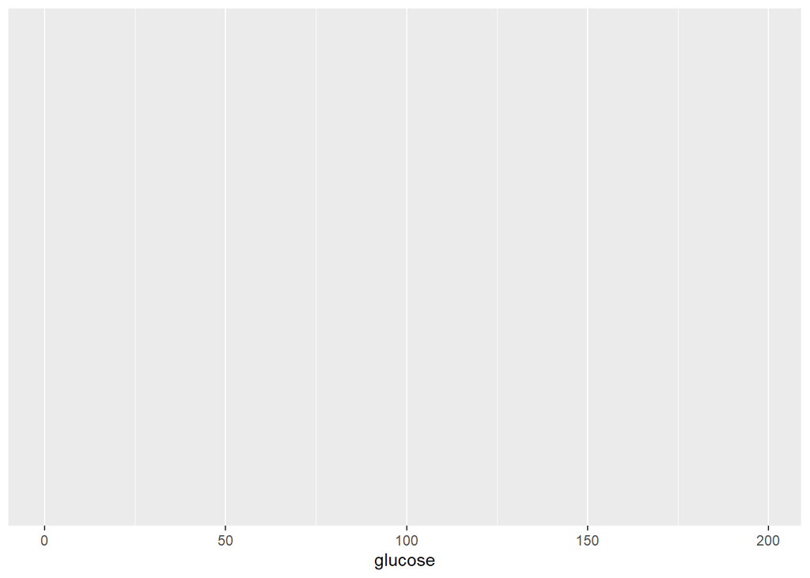

```r
ggplot(data = pima,
       aes(x = glucose))
```

Если вы видите отсутствие графика - это нормально. Дело в том, что для работы ggplot нужна база-подложка для графика. Мы её задали. Теперь нужно понять, а какой тип графика мы хотим нарисовать. Типы графика зависят от используемых векторов. Посмотрим на то, какими они бывают по [ссылке](https://activewizards.com/content/blog/How_to_Choose_the_Right_Chart_Type_%5BInfographic%5D/chart-types-infographics04.png).

…

## Распределение одной числовой переменной

### Histogram

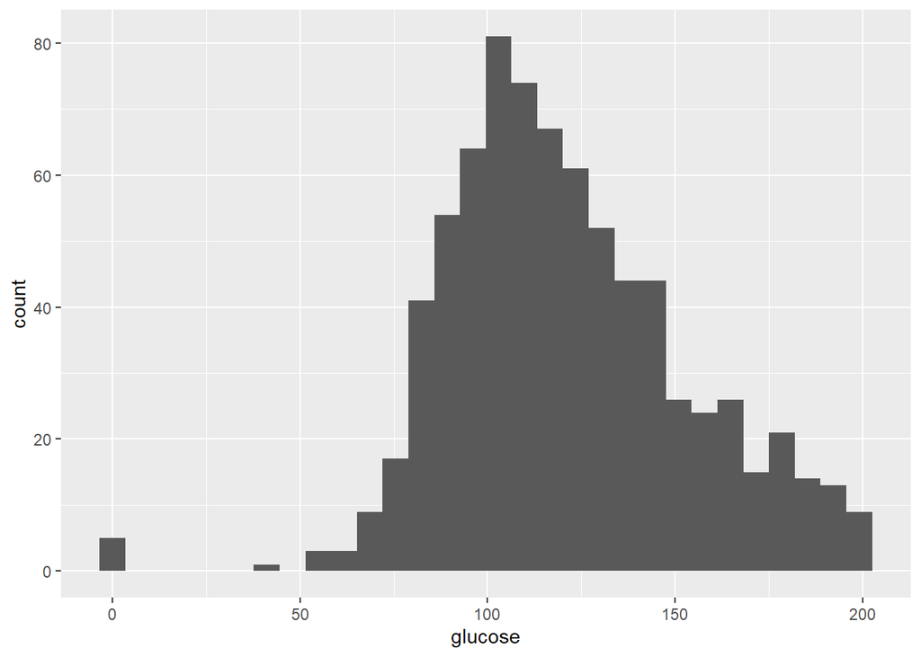

```r
ggplot(data = pima,
       aes(x = glucose)) +
  geom_histogram()
```

### Density plot

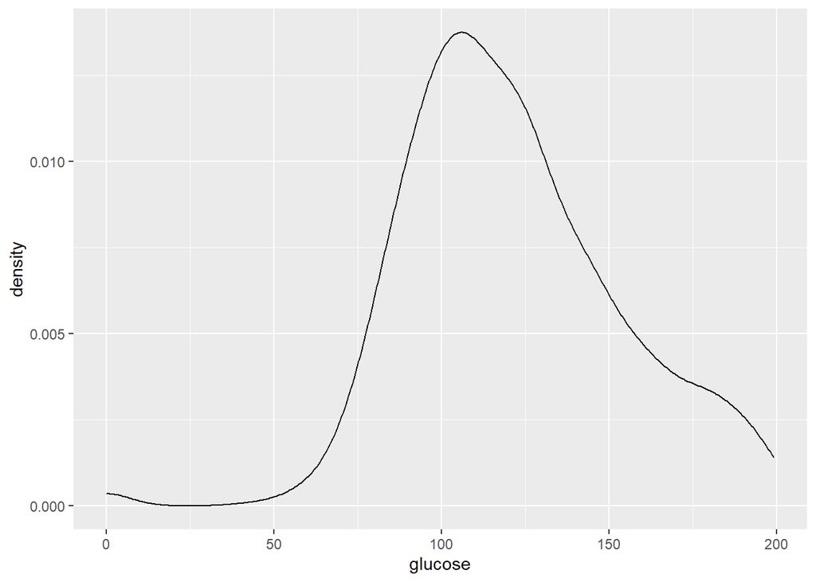

```
Промежуточный итог

Для построения графика вам нужны:

1. Data
2. Aesthetic
3. Plot type indicator (geom)
```

```r
ggplot(data = pima,
       aes(x = glucose)) +
  geom_density()
```

### Box plot

Начнём усложнять эту базовую конструкцию. Пока что, мы не осветили последний популярный способ представления распределения одной переменной - Box plot или “ящик с усами”

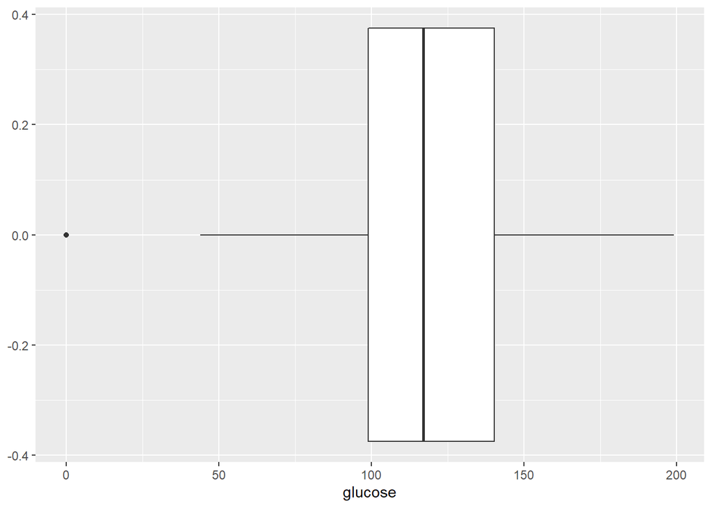

```r
ggplot(data = pima,
       aes(x = glucose)) +
  geom_boxplot()
```

Объясните, что значит этот график?

…

[Подсказка](https://thumb.tildacdn.com/tild3630-3335-4562-a334-393538313035/-/format/webp/Boxplot.jpg).

…

**Одна числовая и одна категориальная переменные**

Усложним график. Добавим вторую переменную по которой мы сделаем разбиение box plot:

```r
ggplot(data = pima,
       aes(x = glucose, y = diabetes_ch)) +
  geom_boxplot()
```

[output not shown]

*ЗАДАНИЕ*

В чанке ниже напишите код для графика распределения индекса массы тела (mass) для возрастных групп в виде box plot

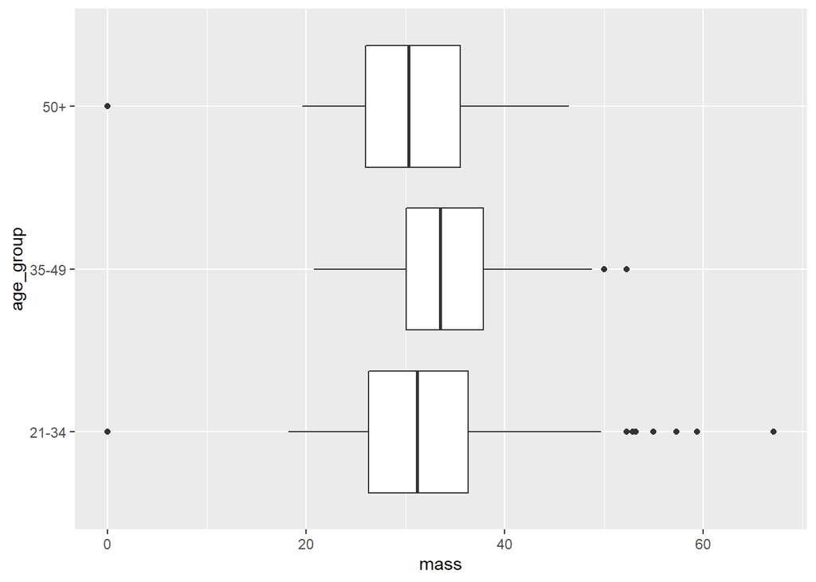

```r
ggplot(data = pima,
       aes(x = mass, y = age_group)) +
  geom_boxplot()
```

…

## Изменене настройки отображения

В ggplot вы можете делать любой график. Давайте посмотрим основные способы изменять график.

- Ggplot - конструктор. Элементы в нём можно переставлять. Например три следующих кода дают по итогам одинаковый график.

```
Опишите, в чём различия кода?
```

```r
# 1
ggplot(data = pima, aes(x = glucose,
                        y = diabetes_ch)) +
  geom_boxplot()
```

```r
# 2
pima %>%
  ggplot(aes(x = glucose, y = diabetes_ch)) +
  geom_boxplot()
```

```r
# 3
ggplot() +
  geom_boxplot(data = pima,
               aes(x = glucose, y = diabetes_ch))
```

…

- Можно менять общую тему (т.е. подготовленный набор настроек). Описания стандартных тем (дополнительные можно подгружать через пакеты или настраивать самостоятельно) [здесь](https://ggplot2.tidyverse.org/reference/ggtheme.html).

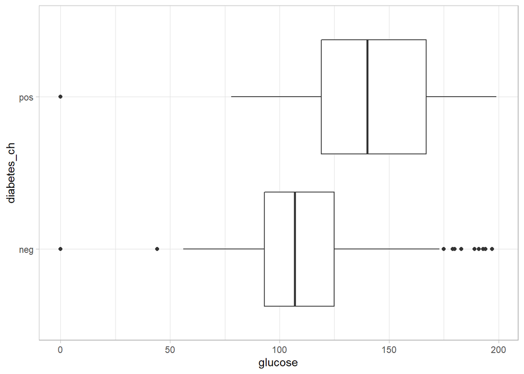

```r
ggplot() +
  geom_boxplot(data = pima,
               aes(x = glucose, y = diabetes_ch)) +
  theme_light()
```

…

- В тех случаях, когда это уместно (например для гистограм или графиков плотности), можно создавать дополнительные объекты информации. Например линию, которая покажет среднюю:

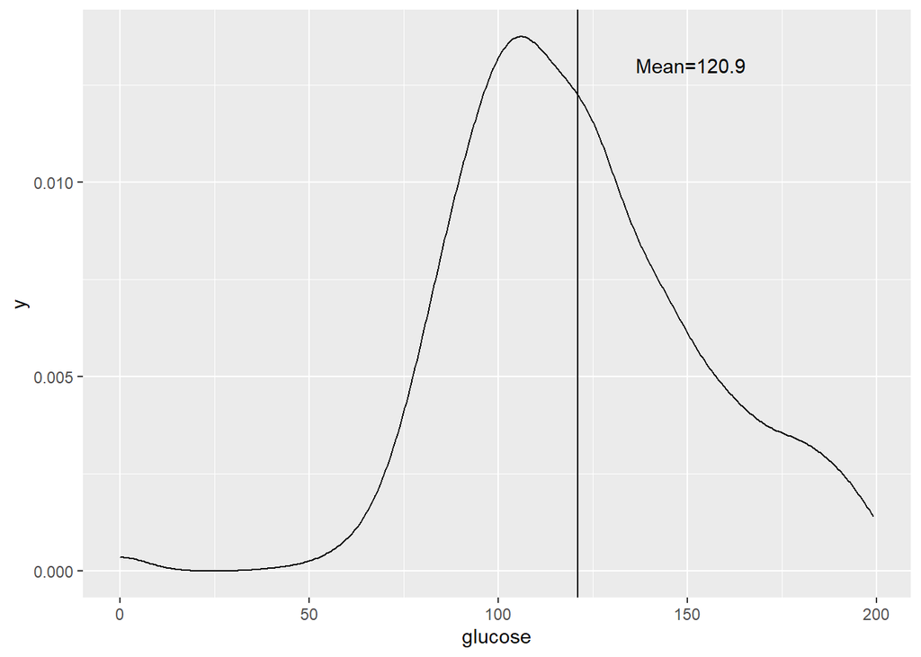

```r
# Найдём среднюю
glucose_mean <- round(mean(pima$glucose),1)

ggplot(data = pima,
       aes(x = glucose)) +
  geom_density() +
  geom_vline(aes(xintercept = glucose_mean)) + #Вертикальная линия
  annotate("text",
           x= glucose_mean+30,
           y=0.013,
           label=paste0("Mean=", glucose_mean))
```

…

- Можно детально изменять тему. Например, настроить размер шрифтов, да и изменить сами названия осей или, например, перевернуть оси!

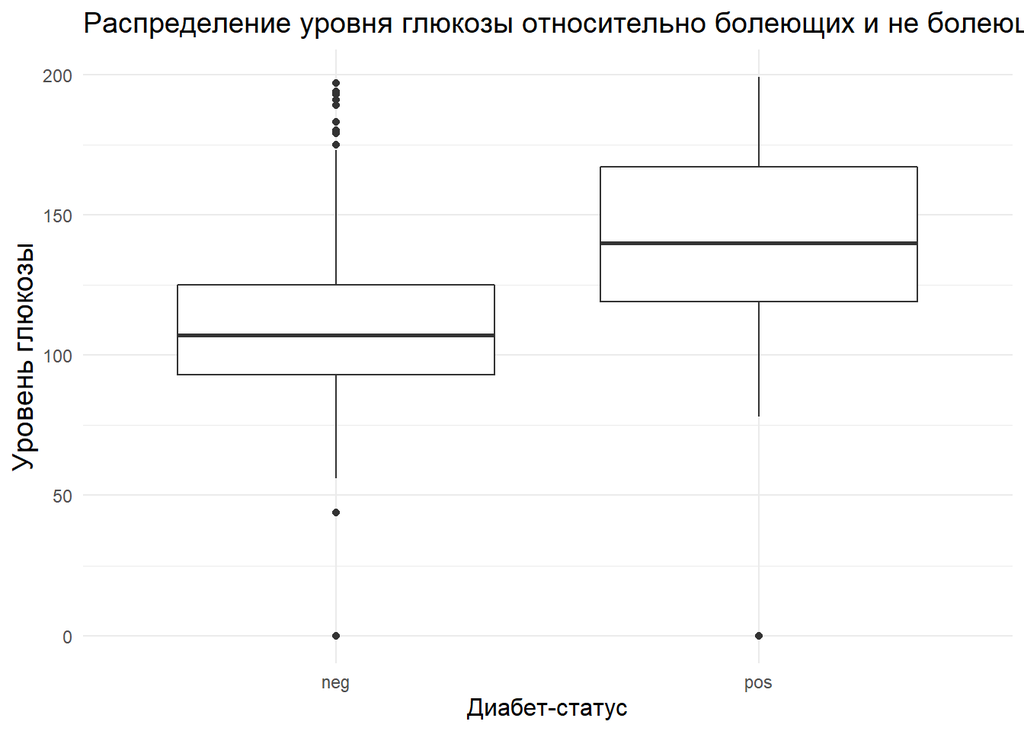

```r
ggplot() +
  geom_boxplot(data = pima,
               aes(x = glucose, y = diabetes_ch)) +
  theme_minimal() +
  ggtitle('Распределение уровня глюкозы относительно болеющих и не болеющих диабетом') +
  labs(y = 'Диабет-статус', x = 'Уровень глюкозы') +
  theme( # Ниже идут настройки тем (их огромное количество, но мы меняем лишь две)
    title = element_text(size = 12), # Задаем стандартный размер текста для любого элемента графика
    axis.title.y = element_text(size=14) # Задаём размер для названия оси y отдельно +
    ) +
  coord_flip() # Переворачиваем оси
```

*ЗАДАНИЕ*

В чанке ниже напишите код для графика распределения числа беременностей в виде гистограммы. Выберете для неё любую [стандуртную тему](https://ggplot2.tidyverse.org/reference/ggtheme.html). Дайте осям графика названия.

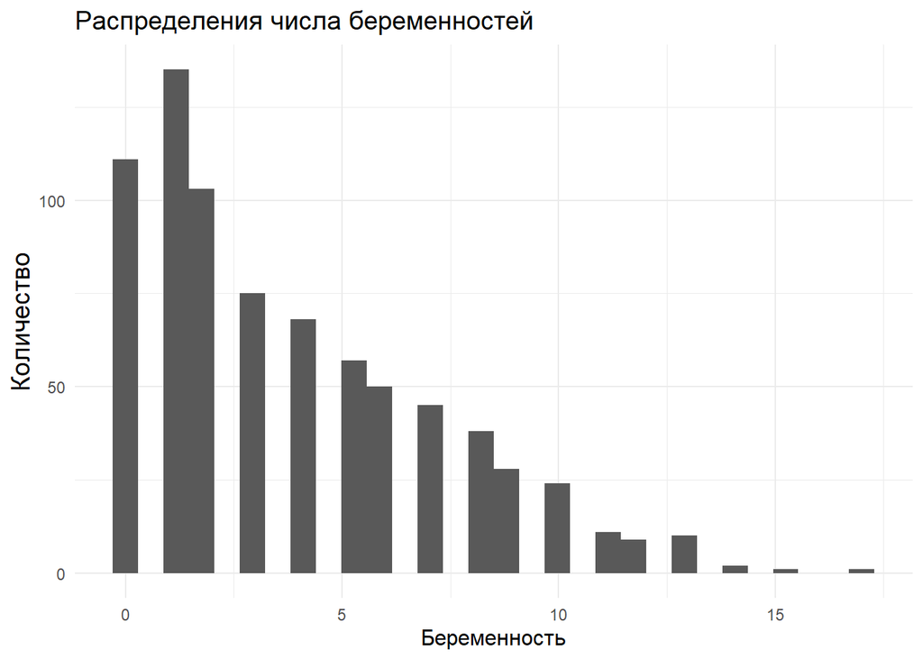

```r
ggplot() +
  geom_histogram(data = pima,
               aes(x = pregnant), bins = 30) +
  theme_minimal() +
  ggtitle('Распределения числа беременностей') +
  labs(x = 'Беременность', y = 'Количество') +
  theme( # Ниже идут настройки тем (их огромное количество, но мы меняем лишь две)
    title = element_text(size = 12), # Задаем стандартный размер текста для любого элемента графика
    axis.title.y = element_text(size=14) # Задаём размер для названия оси y отдельно +
    )
```

…

- Можно задавать цвет для графика. Можно использовать стандартные названия цветов на английском или вставлять специальный код того или иного цвета в формате ‘#номер_кода’. Обратите внимание на разницу ‘color’ и ‘fill’:

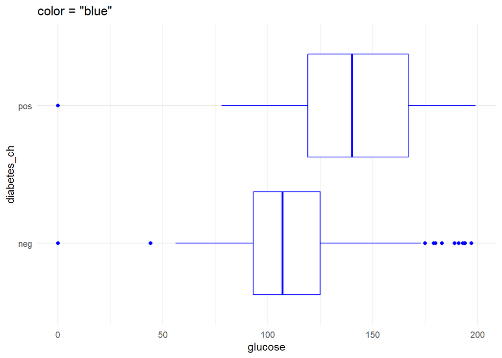

```r
ggplot() +
  geom_boxplot(data = pima,
               aes(x = glucose, y = diabetes_ch),
               color = 'blue') +
  theme_minimal() +
  ggtitle('color = "blue"')
```

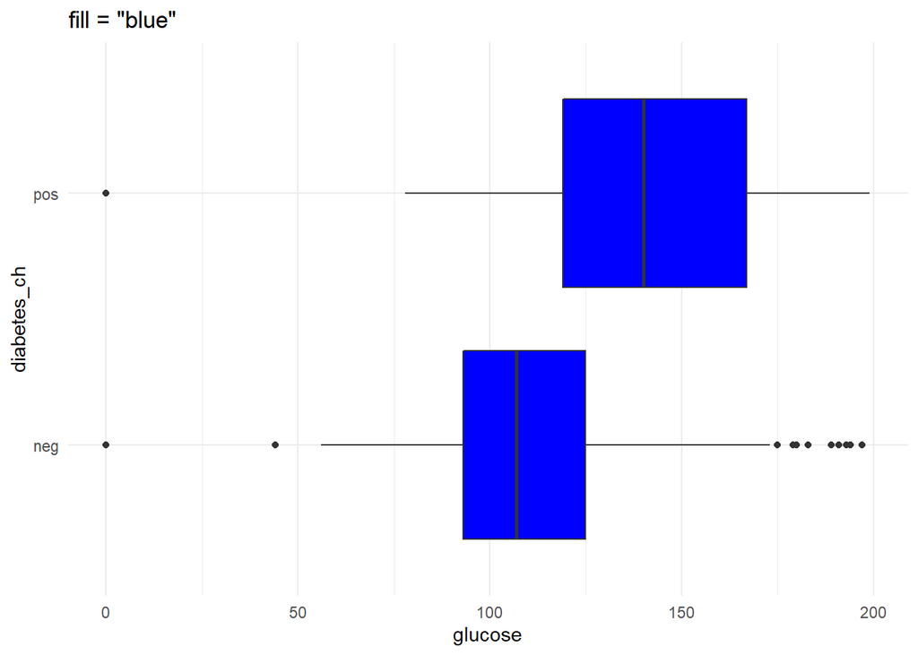

```r
ggplot() +
  geom_boxplot(data = pima,
               aes(x = glucose, y = diabetes_ch),
               fill = 'blue') +
  theme_minimal() +
  ggtitle('fill = "blue"')
```

…

**Одна числовая и две категориальные переменные**

- Но, с помощью закраски можно добавлять для отображения ещё одну переменную! Нужно лишь переместить fill|color в аэстэтики и дать им значение колонки.

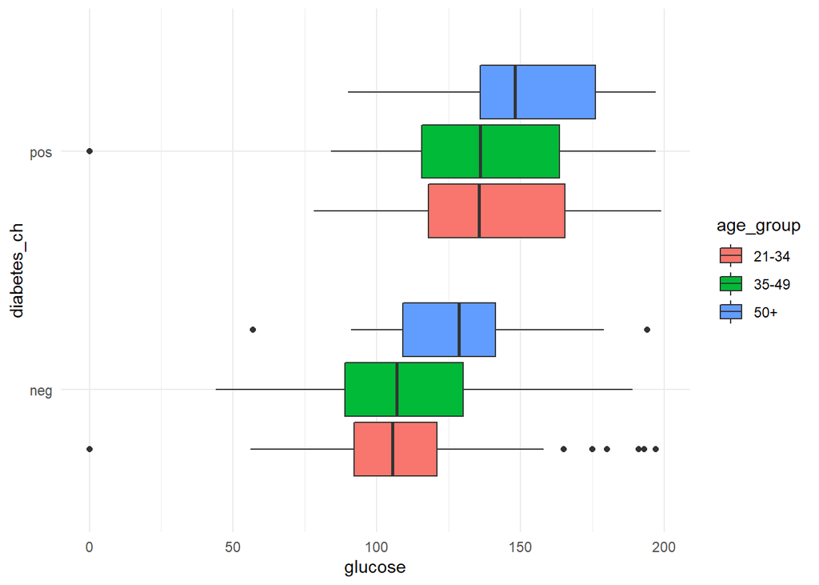

```r
ggplot() +
  geom_boxplot(data = pima,
               aes(x = glucose, y = diabetes_ch, fill = age_group)) +
  theme_minimal()
```

```r
pima
```

[output not shown]

[output cut: 1523 more lines]

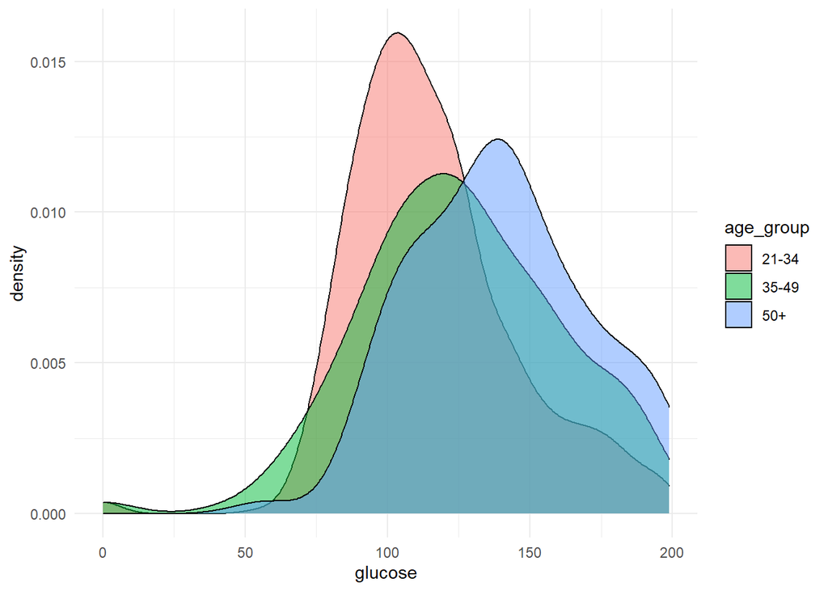

```r
ggplot() +
  geom_density(data = pima,
               aes(x = glucose, fill = age_group),
               alpha = 0.5 # Показатель альфа указывает насколько прозрачным должно быть отображение фигур. Измеряется от 0 до 1.
               ) +
  theme_minimal()
```

*ЗАДАНИЕ*

В чанке ниже напишите код для двух графиков:

1. Распределение возраста. Цвет графика выберете кодом из палитры.
2. Распределение значения инсулина в крови в виде гистограммы, которое будет цветом разбито на возрастные подгруппы. подсказка: в данных в этом смысле будет некоторая проблема, подумайте, как её можно устранить

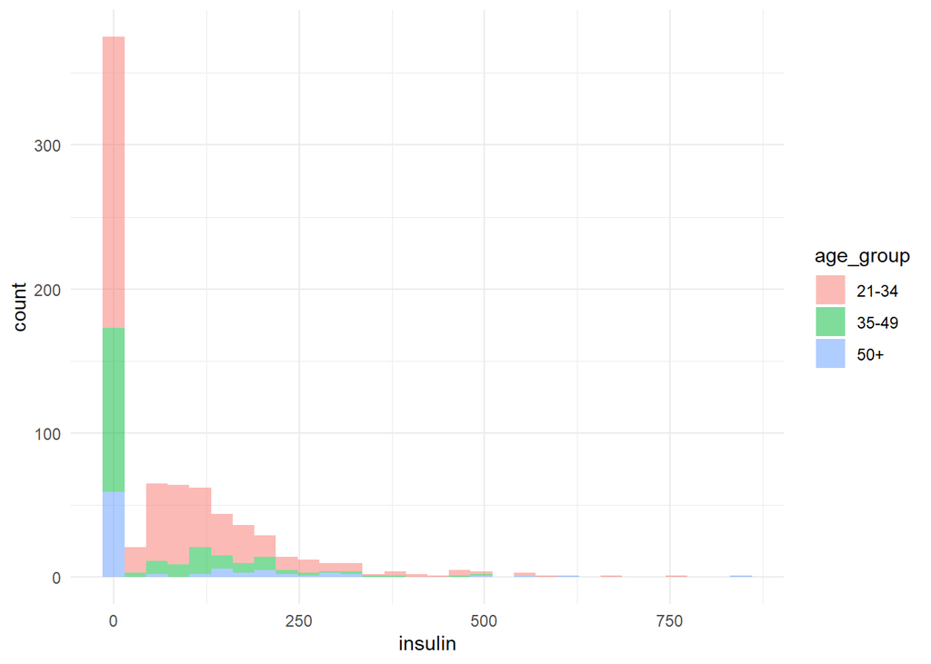

```r
ggplot() +
  geom_histogram(data = pima,
               aes(x = insulin, fill = age_group),
               alpha = 0.5 # Показатель альфа указывает насколько прозрачным должно быть отображение фигур. Измеряется от 0 до 1.
               ) +
  theme_minimal()
```

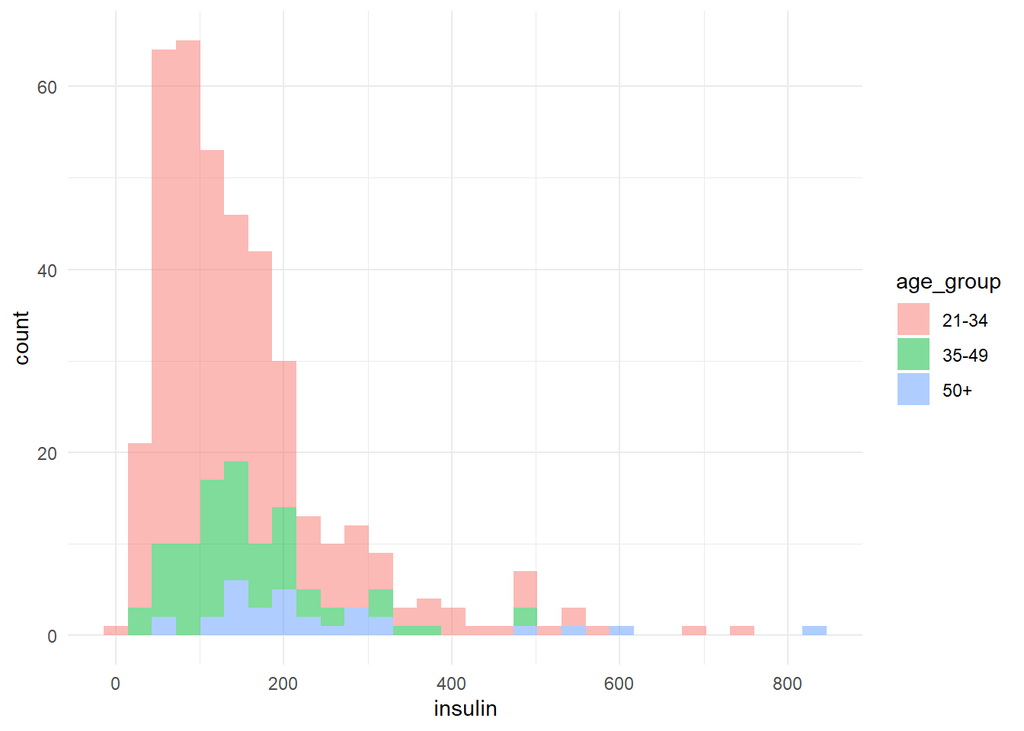

```r
ggplot() +
  geom_histogram(data = pima[pima$insulin != 0,],
               aes(x = insulin, fill = age_group), alpha = 0.5) +
  theme_minimal()
```

…

## Распределение одной номинативной/текстовой переменной

### Bar plot

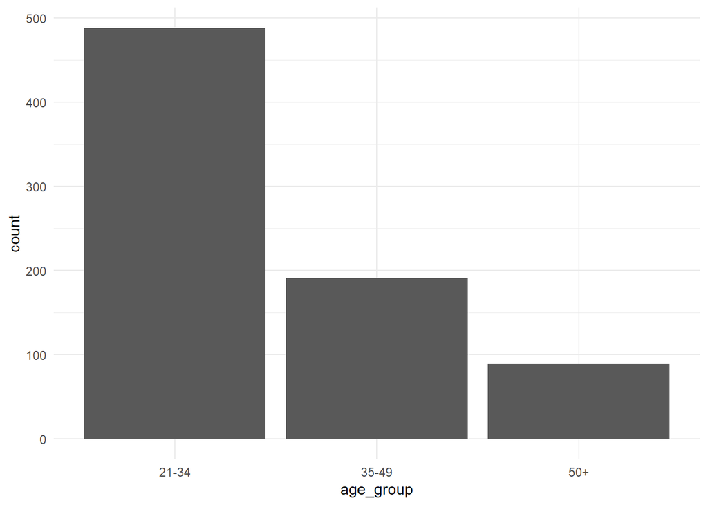

```r
ggplot() +
  geom_bar(data = pima,
           aes(x = age_group)) +
  theme_minimal()
```

…

**Две номинативные переменные**

Если мы хотим сделать разбивку по другой номинативной переменной, также используем “fill”, но с position=“dodge”

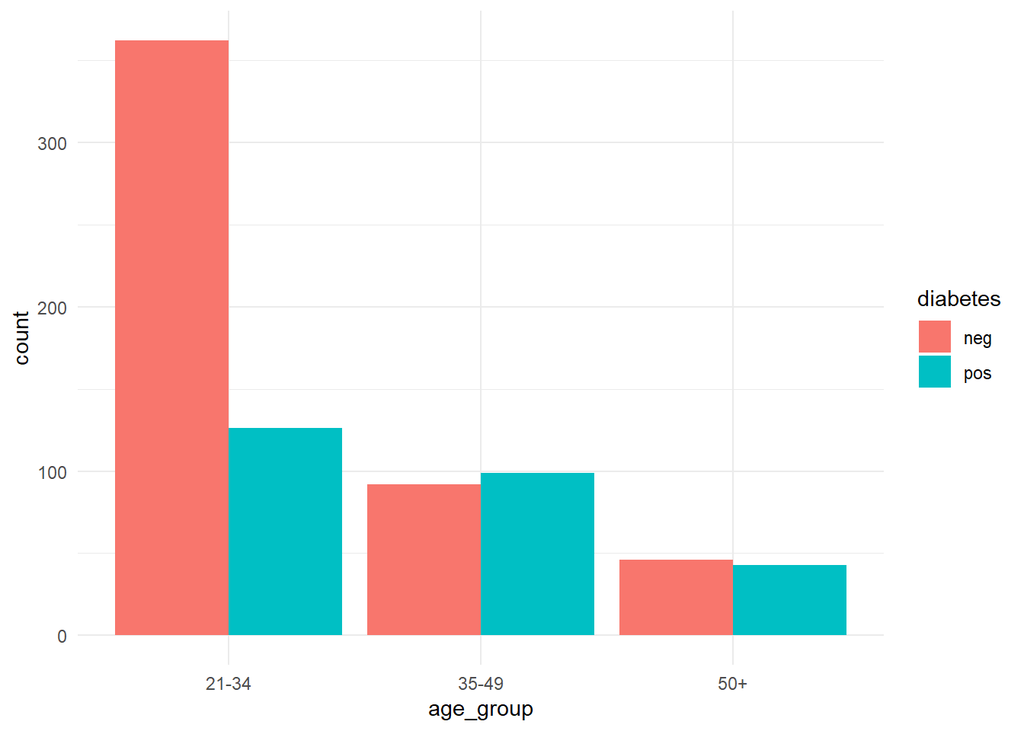

```r
ggplot() +
  geom_bar(data = pima,
           aes(x = age_group, fill = diabetes),
           position="dodge") +
  theme_minimal()
```

*ЗАДАНИЕ*

В чанке ниже создайте номинативную переменную была ли пациентка беремена хотя бы один раз или нет. После этого постройте bar plot в котором визуализируйте эту переменную, а также разбейте её на группы по переменной diabetes

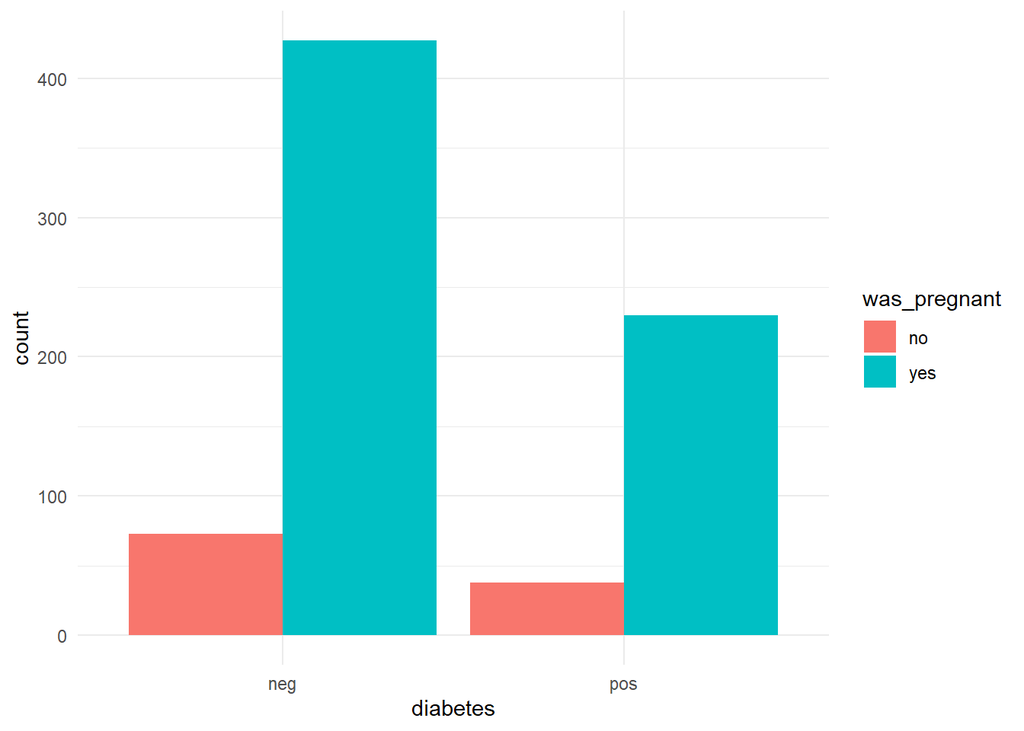

```r
pima$was_pregnant <- ifelse(pima$pregnant == 0, 'no', 'yes')
ggplot() +
  geom_bar(data = pima,
           aes(x = diabetes, fill = was_pregnant),
           position="dodge") +
  theme_minimal()
```

…

## Отношение двух числовых переменных

### Scatter plot

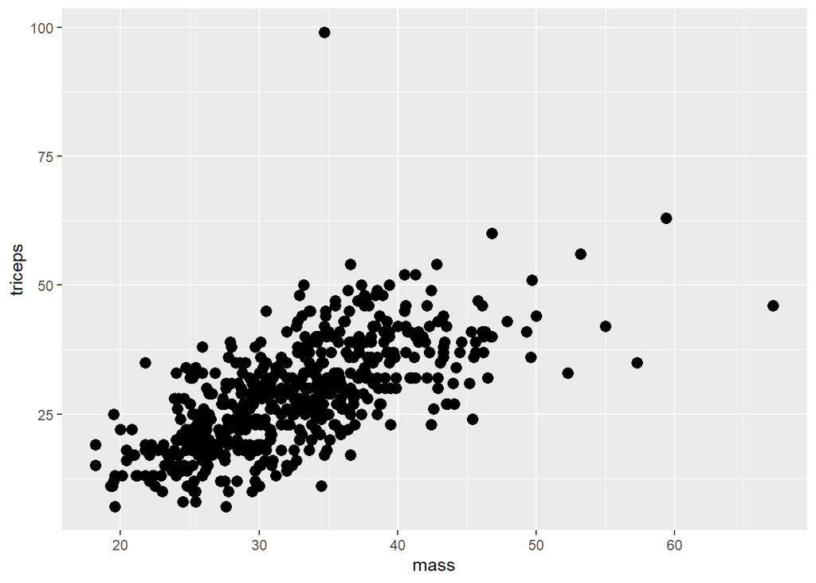

```r
pima %>%
  filter(mass != 0 & triceps != 0) %>%
  ggplot(aes(x=mass, y=triceps)) +
    geom_point(size=3)
```

*ЗАДАНИЕ*

Опираясь на [это](http://www.sthda.com/sthda/RDoc/images/points-symbols.png), добавьте в чанке ниже недостающий элемент “_” к графику.

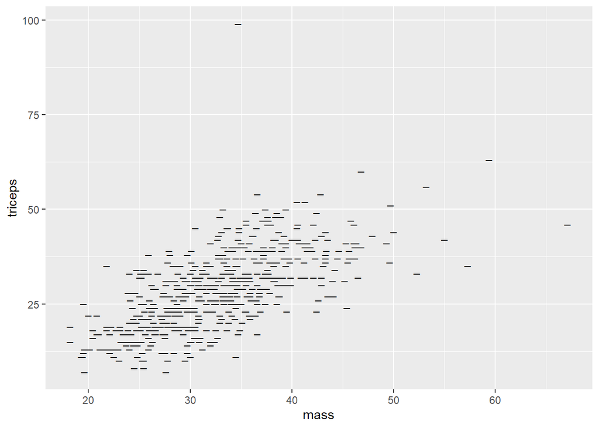

```r
pima %>%
  filter(mass != 0 & triceps != 0) %>%
  ggplot(aes(x=mass, y=triceps)) +
    geom_point(size=3, shape = '_')
```

…

**Три численные переменные**

*ЗАДАНИЕ*

Добавьте отображение третьей численной переменной с помощью градиента цвета по колонке pressure. Для этого вам понадобится аргумент color.

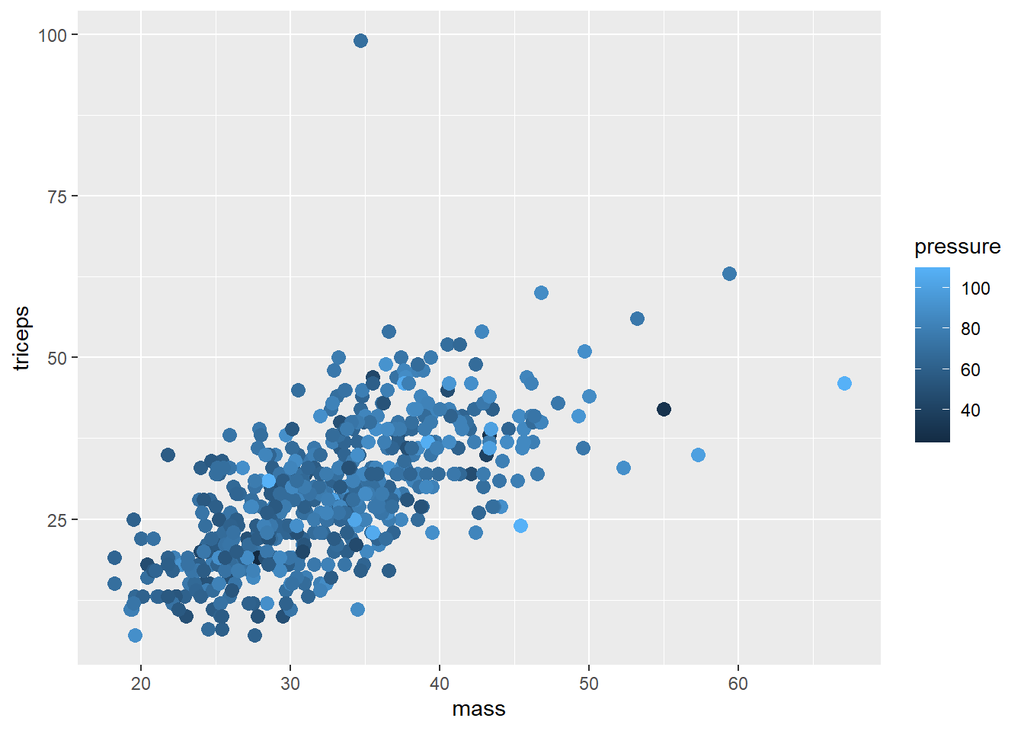

```r
pima %>%
  filter(mass != 0 & triceps != 0 & pressure != 0) %>%
  ggplot() +
    geom_point(size=3,
               aes(x=mass, y=triceps, color = pressure))
```

…

**Две числовые и одна категориальная переменная**

*ЗАДАНИЕ*

В чанке ниже добавьте к предыдущему графику группировку по diabetes. Поэксперементируйте с группировкой не только по “color”, но и по “shape”, “alpha”, “size”.

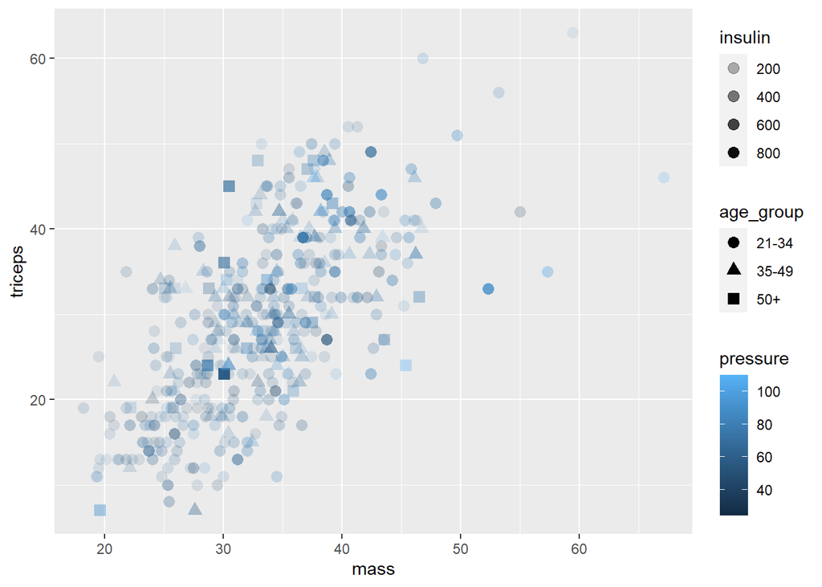

```r
pima %>%
  filter(mass != 0 & triceps != 0 & pressure != 0 & insulin != 0) %>%
  ggplot() +
    geom_point(aes(x=mass, y=triceps, color = pressure, shape = age_group, alpha = insulin, size = pedigree), size=3)
```

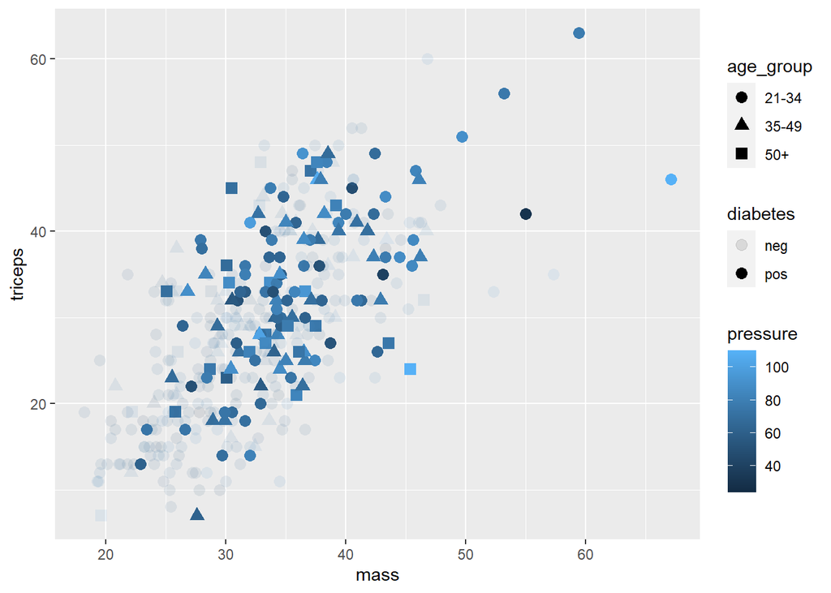

```r
pima %>%
  filter(mass != 0 & triceps != 0 & pressure != 0 & insulin != 0) %>%
  ggplot() +
    geom_point(aes(x=mass, y=triceps, color = pressure, shape = age_group, alpha = diabetes, size=insulin), size=3)
```

…

### Line plot

Отношение одной переменной (обычно связанной со временем) к другой числовой переменной

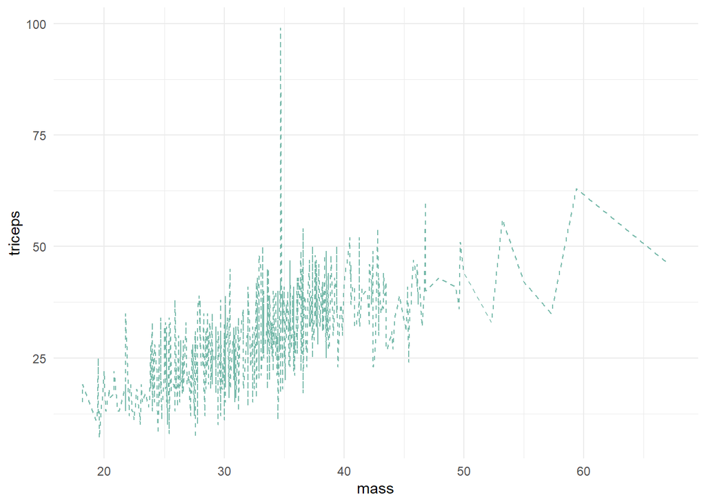

```r
pima %>%
  filter(mass != 0 & triceps != 0) %>%
  ggplot(aes(x=mass, y=triceps)) +
  geom_line( color="#69b3a2", alpha=0.9, linetype=2) +
  theme_minimal()
```

Вышло не идеально. Тут надо либо вручную округлять по отрезкам (например каждые 10 единиц ИМТ), либо воспользоваться трендом (т.е. моделью линейной регрессии или lm). За это отвечает geom_smooth():

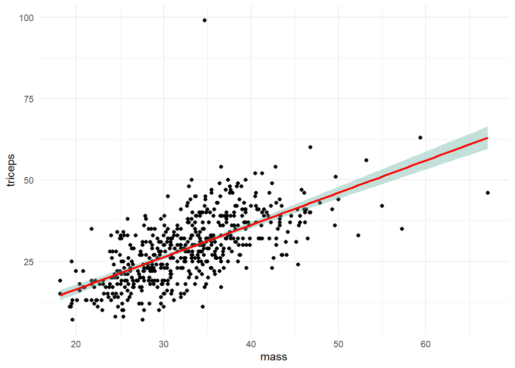

```r
pima %>%
  filter(mass != 0 & triceps != 0) %>%
  ggplot(aes(x=mass, y=triceps)) +
  geom_point() +
  geom_smooth(method=lm, # Выбираем модель. Стандартно - линейная модель
              # formula = y ~ poly(x, 3, raw=TRUE), # Формула. В данном случае приведён полином третьей степени. Поскольку в данных хорошая линейная связь - он не обязателен.
              color="red", fullrange = T,
              fill="#69b3a2",
              se=TRUE # Используем ли доверительные интервалы?
              ) +
  theme_minimal()
```

…

**Две числовые и одна категориальная переменная**

Но и здесь мы также можем усложнять график

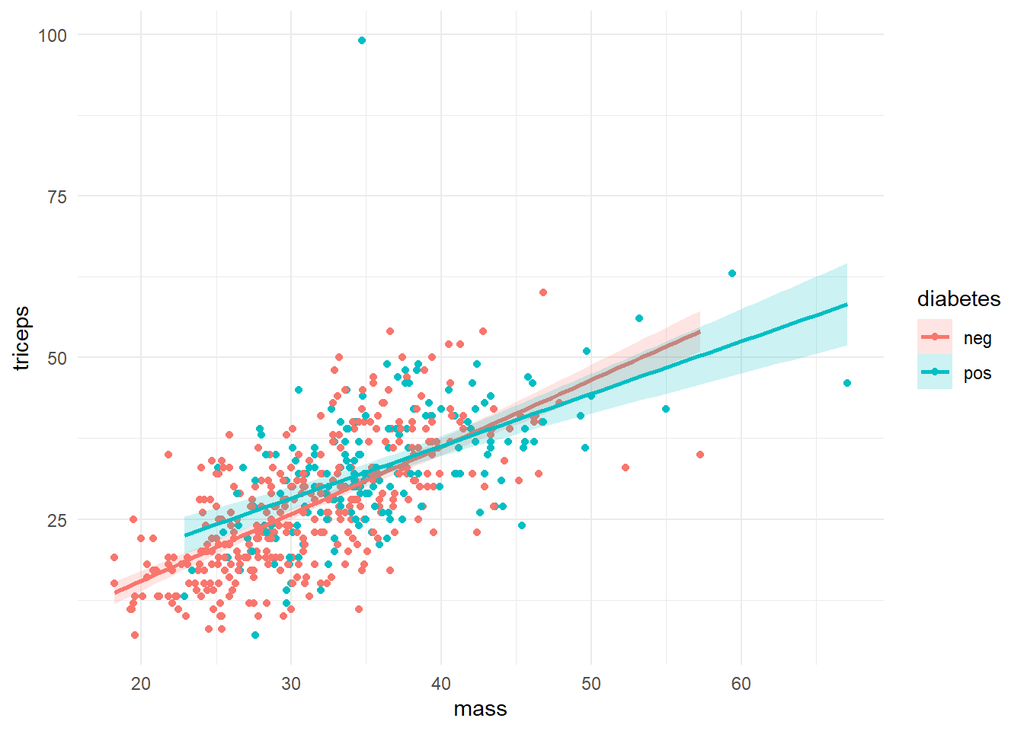

```r
pima %>%
  filter(mass != 0 & triceps != 0) %>%
  ggplot(aes(
    x=mass,
    y=triceps,
    color = diabetes,
    fill = diabetes,
    group = diabetes)) +
  geom_point() +
  geom_smooth(method=lm,
              # fullrange = T, # Протягивать ли линию от края до края или делать её только в границах значений, которые принимает переменная?
              alpha = 0.2,
              se=TRUE
              ) +
  theme_minimal()
```

*ЗАДАНИЕ*

В чанке ниже постройте свой график с регрессионной линией для отношений глюкозы и артериального давления. Сделайте группировку по возрастным группам. Измените размер линий.

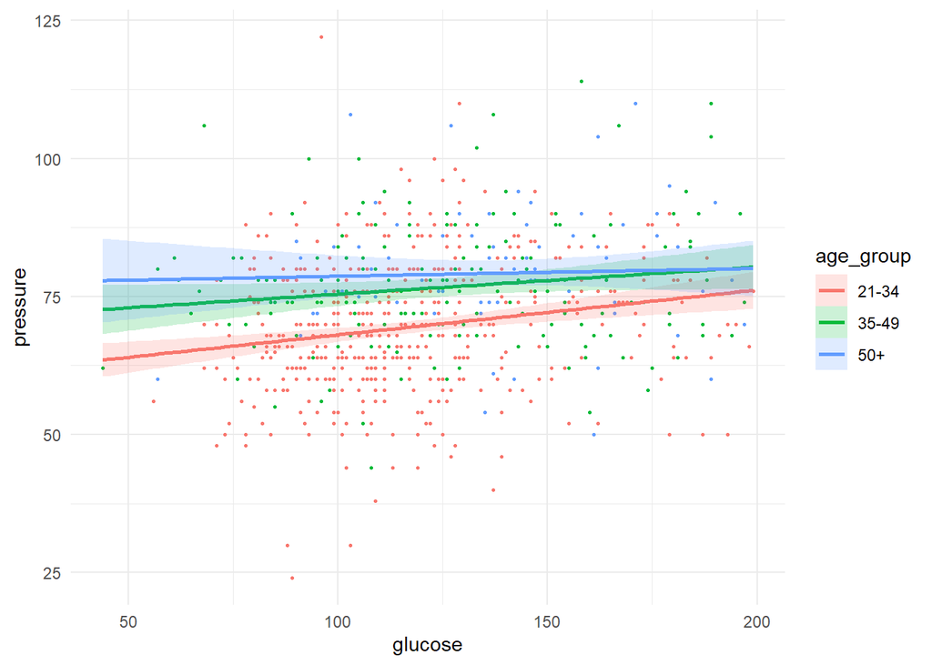

```r
pima %>%
  filter(glucose != 0 & pressure != 0) %>%
  ggplot(aes(
    x = glucose,
    y = pressure,
    color = age_group,
    fill = age_group,
    group = age_group)) +
  geom_point(size = 0.5) +
  geom_smooth(method=lm,
               fullrange = T, # Протягивать ли линию от края до края или делать её только в границах значений, которые принимает переменная?
              alpha = 0.2,
              se=TRUE
              ) +
  theme_minimal()
```

…

## Фасеты

**Две числовые и одна категориальная переменная**

Фасеты это разбивка графика по какой-то категориальной переменной на два или больше графиков (в зависимости от числа категорий в переменной). В результате на каждом графике отображается подвыборка какого-то значения категории.

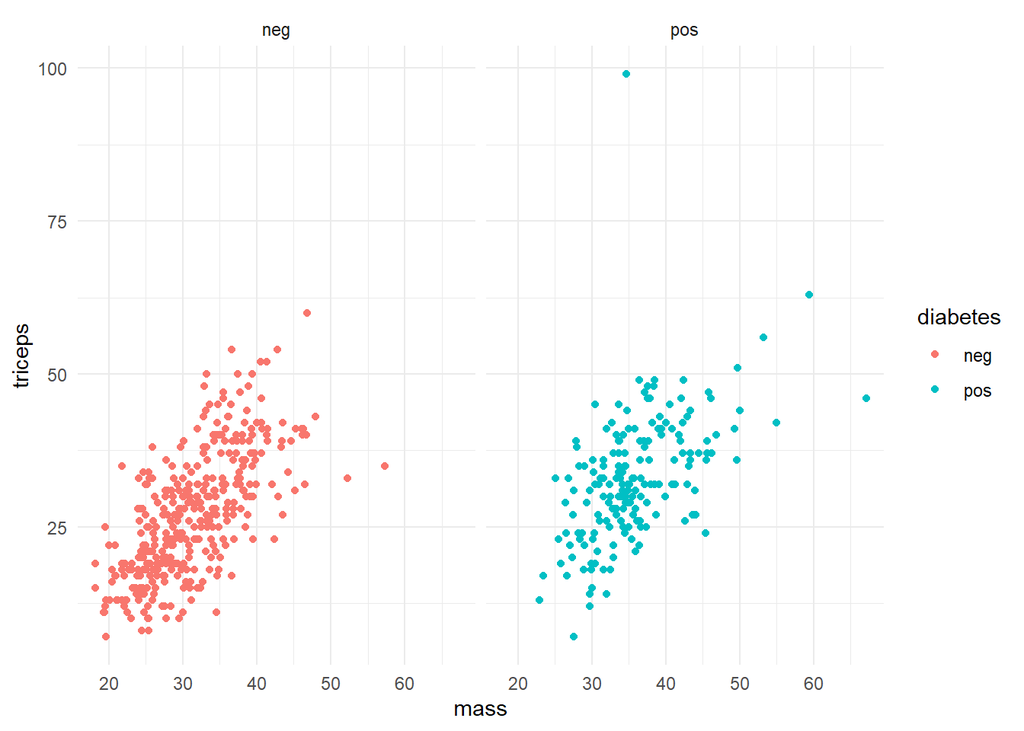

```r
pima %>%
  filter(mass != 0 & triceps != 0) %>%
  ggplot(aes(x=mass, y=triceps, color = diabetes, fill = diabetes, group = diabetes)) +
  geom_point() +
  facet_grid(. ~ diabetes) +
  theme_minimal()
```

## Расположение двух и более разных графиков вместе

Используем функцию ggarrange() из пакета “ggpubr”.

Сохраним наш график по scatter plot и график по bar plot

```r
scatter <- pima %>%
  filter(mass != 0 & triceps != 0) %>%
  ggplot(aes(x=mass, y=triceps)) +
  geom_point(size=3) +
  theme_minimal()

bar <- ggplot() +
  geom_bar(data = pima,
           aes(x = age_group)) +
  theme_minimal()
```

Загрузим библиотеку и объединим графики:

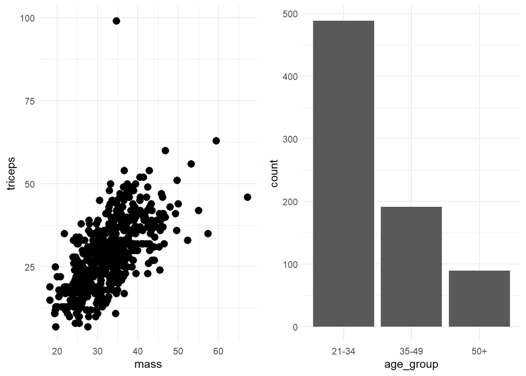

```r
#install.packages('ggpubr')
library(ggpubr)

combine_plot <- ggarrange(scatter, bar,
                          ncol = 2, nrow = 1) # Указываем формат расположения графиков в виде таблицы, где будет 2 ячейки (для графиков) по колонкам и 1 по строке
combine_plot
```

*ЗАДАНИЕ*

В чанке ниже постройте scatter plot уровня инсулина и глюкозы в крови. Разбейте его по возрастным группам. Сохраните. Сделайте второй график density plot по возрасту пациентов. Сохраните. Объедините два графика и покажите результат.

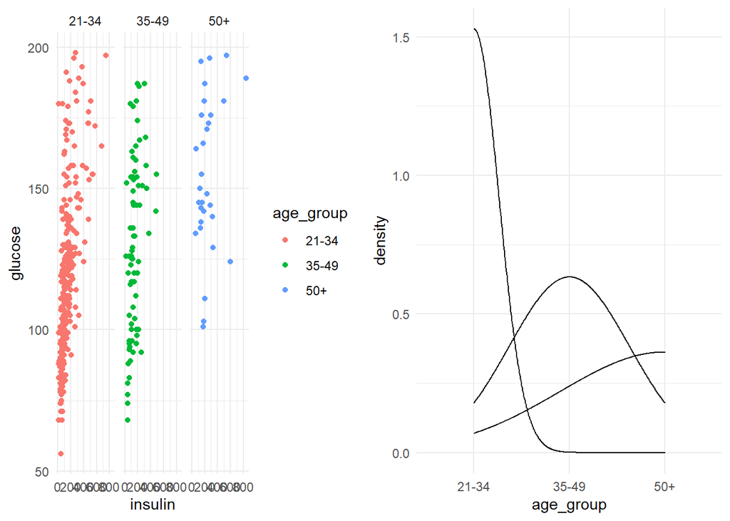

```r
scatter <- pima %>%
  filter(insulin != 0 & glucose != 0) %>%
  ggplot(aes(x=insulin, y=glucose, color = age_group, fill = age_group, group = age_group)) +
  geom_point() +
  facet_grid(. ~ age_group) +
  theme_minimal()

density_plot <- ggplot() +
  geom_density(data = pima,
           aes(x = age_group)) +
  theme_minimal()

combine_plot <- ggarrange(scatter, density_plot,
                          ncol = 2, nrow = 1)

combine_plot
```

# Сохранение графиков

```r
ggsave(
  plot = combine_plot, # Какой объект хотим сохранить?
  "combine_plot.png", # Название файла + указываем формат (можно указать другие популярные форматы)
  width = 8.5, # Ширина картинки
  height = 9, # Высота картинки
  dpi = 1000) # Качество - dots per inch
```

…

# Как выбираем тип графика?

1. Хотим ли мы показать распределение одной перемнной или отношение нескольких?
2. Какие дополнительные переменные структурно могут оказать влияние на те, что интересуют вас? Дополнительные переменные нужно задать через цвет если они числовые и через цвет, форму, размер и проч. если они категориальные.
3. Есть ли какая-то категориальная переменная, которая разбивает данные на осмысленные фасеты?

…

# P.S. Специфические типы графиков (дополнительная темы)

## Геоданные

Геоданные (и пространственный анализ вообще) - отдельная и большая область для работы. Для знакомства с ней приглашаю вам посмотреть лекцию и тетрадку по ссылкам [1](https://meetups.rintro.ru/p/14-may-2022-eu-spb-meetup/), [2](https://tsamsonov.github.io/r-geo-course/).

Базово, что стоит помнить, существует три базовых формата геоданных:

- POINT
- LINESTRING
- POLYGON

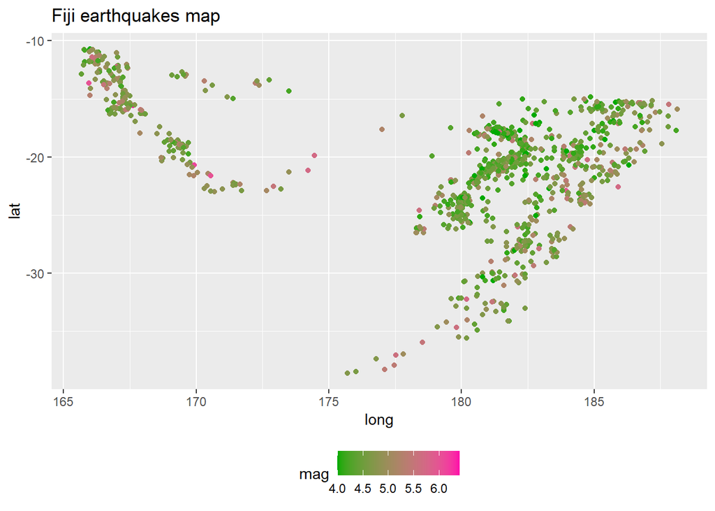

```r
library(maps)
world <- map_data('world') # Датасет из ggplotw о странах мира и их границах. Это данные по полигонам.

earthquakes <- quakes # Предустановленный датасет о точках извержения вулканов на Фиджи магнитудой больше 4 баллов с 1964 г. Это данные по точкам.

# Обрежем данные только по Фиджи и её соседям
fiji <- world[world$region %in% c("Fiji", "New Zealand", "Vanuatu", "Tonga"), ]


### Сделаем наложение одного на другое

# Посмотрим как устроенны карты в первом приближении по точкам.
ggplot() +
  geom_point(data = earthquakes, # Откуда мы берём данные для карты (здесь у нас точки)
             aes(x=long, # Долгота
                 y = lat, # Широта
                 colour = mag)) +
  scale_colour_gradient(low = "#00AA00",high = "#FF00AA") + # Задаём цвета от которого и до которого должен идти градиент по магнитуде
  ggtitle("Fiji earthquakes map ") +
  theme(
    legend.position = "bottom" # Легенда для карты помещена под неё
  )
```

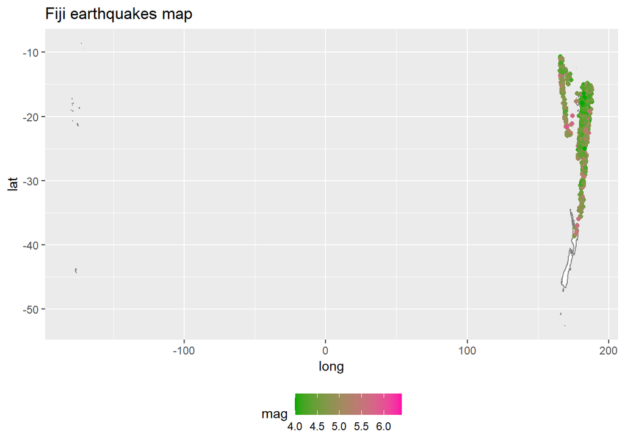

```r
# Добавим границы государств
ggplot() +
  geom_map(data = fiji,
           map = fiji, # Откуда мы берём данные для карты (здесь у нас полигоны)
           aes(x = long, # Долгота
               y=lat, # Широта
               group=group, # Как мы группируем строки в полигоны
               map_id=region # Через что мы обращаемся к тому или иному полигону
               ),
           fill="white", colour="#7f7f7f", size=0.5) +
  geom_point(data = earthquakes, # Здесь у нас точки и все становится проще
             aes(x=long,
                 y = lat,
                 colour = mag)) +
  scale_colour_gradient(low = "#00AA00",high = "#FF00AA") + # Задаём цвета от которого и до которого должен идти градиент по магнитуде
  ggtitle("Fiji earthquakes map ") +
  theme(
    legend.position = "bottom" # Легенда для карты помещена под неё
  )
```

Далее всё становится сложнее и стоит копать в пакеты sf и ggmap.

…

# Полезные ссылки

- [Книга-гайд](http://www.cookbook-r.com/Graphs/) по ggplot;
- [Мастицкий С.Э. - Визуализация данных с помощью ggplot2](https://dmkpress.com/catalog/computer/statistics/978-5-97060-470-0/)
- [Балтыжакова Т. - Визуализируй это: визуализация данных в R](https://baltti.github.io/workshop-DH21/ggplot2-tutorial-DH.html)
- [Рассказ](https://www.datanovia.com/en/blog/top-r-color-palettes-to-know-for-great-data-visualization/) про фирменные палетки (сочетания цветов для графиков) R;
- [Ресурс](https://coolors.co/0d3b66-faf0ca-f4d35e-ee964b-f95738), где можно собрать свою палетку;